# Project: Investigating a Dataset of No-show appointments in Brazil.

- Introduction
- Data Wrangling
- Exploratory Data Analysis
- Conclusions

# Asking Questions

### Is having a scholarship in brasil famillia affect the attending ratio

### Does SMS messages influence attendance ?

### Does male and female ratio attendance differ ?

```python
# Use this cell to set up import statements for all of the packages that you
#   plan to use.
import pandas as pd
import numpy as np
import matplotlib.pyplot as plt
import seaborn as sns
%matplotlib inline

df = pd.read_csv('project2.csv')
plt.style.use("ggplot")
```

## Data Wrangling

> **Tip**: In this section of the report, you will load in the data, check for cleanliness, and then trim and clean your dataset for analysis. Make sure that you document your steps carefully and justify your cleaning decisions.

### General Properties

```python
# Load your data and print out a few lines. Perform operations to inspect data
df.head()
```

|  | PatientId | AppointmentID | Gender | ScheduledDay | AppointmentDay | Age | Neighbourhood | Scholarship | Hipertension | Diabetes | Alcoholism | Handcap | SMS_received | No-show |
| --- | --- | --- | --- | --- | --- | --- | --- | --- | --- | --- | --- | --- | --- | --- |
| 0 | 2.987250e+13 | 5642903 | F | 2016-04-29T18:38:08Z | 2016-04-29T00:00:00Z | 62 | JARDIM DA PENHA | 0 | 1 | 0 | 0 | 0 | 0 | No |
| 1 | 5.589978e+14 | 5642503 | M | 2016-04-29T16:08:27Z | 2016-04-29T00:00:00Z | 56 | JARDIM DA PENHA | 0 | 0 | 0 | 0 | 0 | 0 | No |
| 2 | 4.262962e+12 | 5642549 | F | 2016-04-29T16:19:04Z | 2016-04-29T00:00:00Z | 62 | MATA DA PRAIA | 0 | 0 | 0 | 0 | 0 | 0 | No |
| 3 | 8.679512e+11 | 5642828 | F | 2016-04-29T17:29:31Z | 2016-04-29T00:00:00Z | 8 | PONTAL DE CAMBURI | 0 | 0 | 0 | 0 | 0 | 0 | No |
| 4 | 8.841186e+12 | 5642494 | F | 2016-04-29T16:07:23Z | 2016-04-29T00:00:00Z | 56 | JARDIM DA PENHA | 0 | 1 | 1 | 0 | 0 | 0 | No |

```python
#   types and look for instances of missing or possibly errant data.
df.dtypes
```

```
PatientId         float64
AppointmentID       int64
Gender             object
ScheduledDay       object
AppointmentDay     object
Age                 int64
Neighbourhood      object
Scholarship         int64
Hipertension        int64
Diabetes            int64
Alcoholism          int64
Handcap             int64
SMS_received        int64
No-show            object
dtype: object
```

```python
df.info()
```

```
<class 'pandas.core.frame.DataFrame'>
RangeIndex: 110527 entries, 0 to 110526
Data columns (total 14 columns):
 #   Column          Non-Null Count   Dtype
---  ------          --------------   -----
 0   PatientId       110527 non-null  float64
 1   AppointmentID   110527 non-null  int64
 2   Gender          110527 non-null  object
 3   ScheduledDay    110527 non-null  object
 4   AppointmentDay  110527 non-null  object
 5   Age             110527 non-null  int64
 6   Neighbourhood   110527 non-null  object
 7   Scholarship     110527 non-null  int64
 8   Hipertension    110527 non-null  int64
 9   Diabetes        110527 non-null  int64
 10  Alcoholism      110527 non-null  int64
 11  Handcap         110527 non-null  int64
 12  SMS_received    110527 non-null  int64
 13  No-show         110527 non-null  object
dtypes: float64(1), int64(8), object(5)
memory usage: 11.8+ MB
```

### Changing Date columns Data type from object to Datetime

```python
df['AppointmentDay']=pd.to_datetime(df['AppointmentDay'])
df['ScheduledDay']=pd.to_datetime(df['ScheduledDay'])
df['Hypertension']=df['Hipertension']

df.drop("Hipertension",axis=1,inplace=True)
```

```python
df.head()
```

|  | PatientId | AppointmentID | Gender | ScheduledDay | AppointmentDay | Age | Neighbourhood | Scholarship | Diabetes | Alcoholism | Handcap | SMS_received | No-show | Hypertension |
| --- | --- | --- | --- | --- | --- | --- | --- | --- | --- | --- | --- | --- | --- | --- |
| 0 | 2.987250e+13 | 5642903 | F | 2016-04-29 18:38:08+00:00 | 2016-04-29 00:00:00+00:00 | 62 | JARDIM DA PENHA | 0 | 0 | 0 | 0 | 0 | No | 1 |
| 1 | 5.589978e+14 | 5642503 | M | 2016-04-29 16:08:27+00:00 | 2016-04-29 00:00:00+00:00 | 56 | JARDIM DA PENHA | 0 | 0 | 0 | 0 | 0 | No | 0 |
| 2 | 4.262962e+12 | 5642549 | F | 2016-04-29 16:19:04+00:00 | 2016-04-29 00:00:00+00:00 | 62 | MATA DA PRAIA | 0 | 0 | 0 | 0 | 0 | No | 0 |
| 3 | 8.679512e+11 | 5642828 | F | 2016-04-29 17:29:31+00:00 | 2016-04-29 00:00:00+00:00 | 8 | PONTAL DE CAMBURI | 0 | 0 | 0 | 0 | 0 | No | 0 |
| 4 | 8.841186e+12 | 5642494 | F | 2016-04-29 16:07:23+00:00 | 2016-04-29 00:00:00+00:00 | 56 | JARDIM DA PENHA | 0 | 1 | 0 | 0 | 0 | No | 1 |

### This shows that the dataset didnt have any NA values or duplicated rows.

```python
df.isna().sum()
```

```
PatientId         0
AppointmentID     0
Gender            0
ScheduledDay      0
AppointmentDay    0
Age               0
Neighbourhood     0
Scholarship       0
Diabetes          0
Alcoholism        0
Handcap           0
SMS_received      0
No-show           0
Hypertension      0
dtype: int64
```

```python
df.duplicated().sum()
```

```
0
```

### Checking for duplicated patient IDs

```python
df['PatientId'].duplicated().sum()
```

```
48228
```

##### There are a lot of duplicated IDs. Lets check if their attendance is recurring

```python
df.duplicated(['PatientId','No-show']).sum()
```

```
38710
```

#### Lets drop these as they are ruining our data.

```python
df.describe()
```

|  | PatientId | AppointmentID | Age | Scholarship | Diabetes | Alcoholism | Handcap | SMS_received | Hypertension |
| --- | --- | --- | --- | --- | --- | --- | --- | --- | --- |
| count | 1.105270e+05 | 1.105270e+05 | 110527.000000 | 110527.000000 | 110527.000000 | 110527.000000 | 110527.000000 | 110527.000000 | 110527.000000 |
| mean | 1.474963e+14 | 5.675305e+06 | 37.088874 | 0.098266 | 0.071865 | 0.030400 | 0.022248 | 0.321026 | 0.197246 |
| std | 2.560949e+14 | 7.129575e+04 | 23.110205 | 0.297675 | 0.258265 | 0.171686 | 0.161543 | 0.466873 | 0.397921 |
| min | 3.921784e+04 | 5.030230e+06 | -1.000000 | 0.000000 | 0.000000 | 0.000000 | 0.000000 | 0.000000 | 0.000000 |
| 25% | 4.172614e+12 | 5.640286e+06 | 18.000000 | 0.000000 | 0.000000 | 0.000000 | 0.000000 | 0.000000 | 0.000000 |
| 50% | 3.173184e+13 | 5.680573e+06 | 37.000000 | 0.000000 | 0.000000 | 0.000000 | 0.000000 | 0.000000 | 0.000000 |
| 75% | 9.439172e+13 | 5.725524e+06 | 55.000000 | 0.000000 | 0.000000 | 0.000000 | 0.000000 | 1.000000 | 0.000000 |
| max | 9.999816e+14 | 5.790484e+06 | 115.000000 | 1.000000 | 1.000000 | 1.000000 | 4.000000 | 1.000000 | 1.000000 |

### As you have noticed there is a row with age -1 which is insensible data. And so I am going to drop that row while cleaning.

```python
df.groupby(['Age']).count()
```

| Age | PatientId | AppointmentID | Gender | ScheduledDay | AppointmentDay | Neighbourhood | Scholarship | Diabetes | Alcoholism | Handcap | SMS_received | No-show | Hypertension |
| --- | --- | --- | --- | --- | --- | --- | --- | --- | --- | --- | --- | --- | --- |
| -1 | 1 | 1 | 1 | 1 | 1 | 1 | 1 | 1 | 1 | 1 | 1 | 1 | 1 |
| 0 | 3539 | 3539 | 3539 | 3539 | 3539 | 3539 | 3539 | 3539 | 3539 | 3539 | 3539 | 3539 | 3539 |
| 1 | 2273 | 2273 | 2273 | 2273 | 2273 | 2273 | 2273 | 2273 | 2273 | 2273 | 2273 | 2273 | 2273 |
| 2 | 1618 | 1618 | 1618 | 1618 | 1618 | 1618 | 1618 | 1618 | 1618 | 1618 | 1618 | 1618 | 1618 |
| 3 | 1513 | 1513 | 1513 | 1513 | 1513 | 1513 | 1513 | 1513 | 1513 | 1513 | 1513 | 1513 | 1513 |
| ... | ... | ... | ... | ... | ... | ... | ... | ... | ... | ... | ... | ... | ... |
| 98 | 6 | 6 | 6 | 6 | 6 | 6 | 6 | 6 | 6 | 6 | 6 | 6 | 6 |
| 99 | 1 | 1 | 1 | 1 | 1 | 1 | 1 | 1 | 1 | 1 | 1 | 1 | 1 |
| 100 | 4 | 4 | 4 | 4 | 4 | 4 | 4 | 4 | 4 | 4 | 4 | 4 | 4 |
| 102 | 2 | 2 | 2 | 2 | 2 | 2 | 2 | 2 | 2 | 2 | 2 | 2 | 2 |
| 115 | 5 | 5 | 5 | 5 | 5 | 5 | 5 | 5 | 5 | 5 | 5 | 5 | 5 |

104 rows × 13 columns

### This basically makes show column easier to unerstand with YES=1 NO=0 this will help in counting and sum of people that showed for the appointment hence better in visualizing as well.

```python
df=df.drop_duplicates(['PatientId','No-show'])
df.shape
```

```
(71817, 14)
```

```python
df['show']=df['No-show'].replace({'No': 1, 'Yes': 0})
```

### Here I basically make a small query to get rows with the Age = -1 to drop this row.

```python
bad_Age=df[df['Age'] == -1]
bad_Age
```

|  | PatientId | AppointmentID | Gender | ScheduledDay | AppointmentDay | Age | Neighbourhood | Scholarship | Diabetes | Alcoholism | Handcap | SMS_received | No-show | Hypertension | show |
| --- | --- | --- | --- | --- | --- | --- | --- | --- | --- | --- | --- | --- | --- | --- | --- |
| 99832 | 4.659432e+14 | 5775010 | F | 2016-06-06 08:58:13+00:00 | 2016-06-06 00:00:00+00:00 | -1 | ROMÃO | 0 | 0 | 0 | 0 | 0 | No | 0 | 1 |

```python
df.index[df['Age'] == -1].tolist()
```

```
[99832]
```

```python
df.drop([99832], inplace=True)
```

### making sure the row is gone. Its gone!

```python
df.Age.value_counts()
```

```
0      2401
1      1614
2      1189
3      1067
5      1050
       ...
98        5
115       3
100       3
102       2
99        1
Name: Age, Length: 103, dtype: int64
```

## I have noticed that there are some columns that might not be of use in my data analysis process so I will go ahead and drop them.

```python
df.drop(["PatientId","AppointmentID","ScheduledDay","AppointmentDay"],axis=1,inplace=True)
```

```python
df.head(1)
```

|  | Gender | Age | Neighbourhood | Scholarship | Diabetes | Alcoholism | Handcap | SMS_received | No-show | Hypertension | show |
| --- | --- | --- | --- | --- | --- | --- | --- | --- | --- | --- | --- |
| 0 | F | 62 | JARDIM DA PENHA | 0 | 0 | 0 | 0 | 0 | No | 1 | 1 |

```python
df.rename(columns={'No-show':'No_show'},inplace=True)
```

```python
df.head()
```

|  | Gender | Age | Neighbourhood | Scholarship | Diabetes | Alcoholism | Handcap | SMS_received | No_show | Hypertension | show |
| --- | --- | --- | --- | --- | --- | --- | --- | --- | --- | --- | --- |
| 0 | F | 62 | JARDIM DA PENHA | 0 | 0 | 0 | 0 | 0 | No | 1 | 1 |
| 1 | M | 56 | JARDIM DA PENHA | 0 | 0 | 0 | 0 | 0 | No | 0 | 1 |
| 2 | F | 62 | MATA DA PRAIA | 0 | 0 | 0 | 0 | 0 | No | 0 | 1 |
| 3 | F | 8 | PONTAL DE CAMBURI | 0 | 0 | 0 | 0 | 0 | No | 0 | 1 |
| 4 | F | 56 | JARDIM DA PENHA | 0 | 1 | 0 | 0 | 0 | No | 1 | 1 |

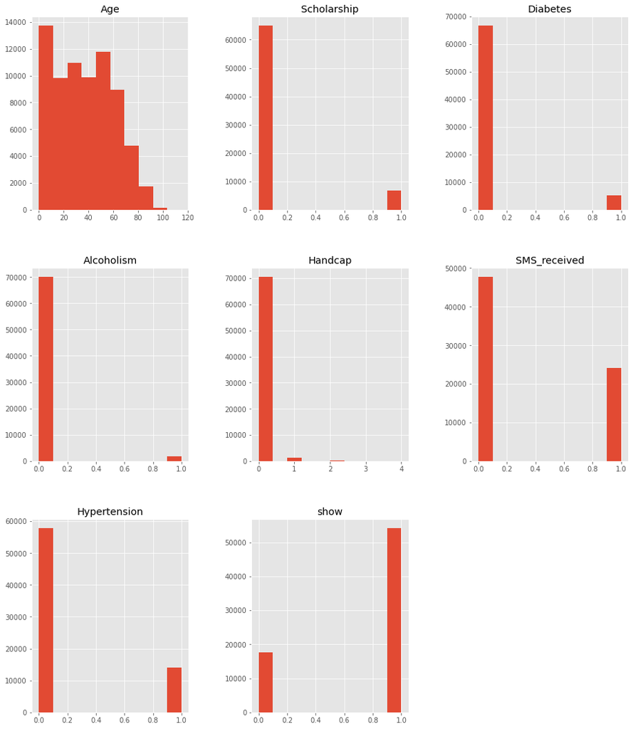

```python
df.hist(figsize=(15,10))
plt.subplots_adjust(plt.subplots_adjust(left=0.1,
                    bottom=0.1,
                    right=0.9,
                    top=1.5,
                    wspace=0.4,
                    hspace=0.3))
```

```python
df.describe()
```

|  | Age | Scholarship | Diabetes | Alcoholism | Handcap | SMS_received | Hypertension | show |
| --- | --- | --- | --- | --- | --- | --- | --- | --- |
| count | 71816.000000 | 71816.000000 | 71816.000000 | 71816.000000 | 71816.000000 | 71816.000000 | 71816.000000 | 71816.000000 |
| mean | 36.527501 | 0.095536 | 0.070959 | 0.025036 | 0.020135 | 0.335566 | 0.195068 | 0.754052 |
| std | 23.378262 | 0.293956 | 0.256758 | 0.156236 | 0.155338 | 0.472191 | 0.396256 | 0.430651 |
| min | 0.000000 | 0.000000 | 0.000000 | 0.000000 | 0.000000 | 0.000000 | 0.000000 | 0.000000 |
| 25% | 17.000000 | 0.000000 | 0.000000 | 0.000000 | 0.000000 | 0.000000 | 0.000000 | 1.000000 |
| 50% | 36.000000 | 0.000000 | 0.000000 | 0.000000 | 0.000000 | 0.000000 | 0.000000 | 1.000000 |
| 75% | 55.000000 | 0.000000 | 0.000000 | 0.000000 | 0.000000 | 1.000000 | 0.000000 | 1.000000 |
| max | 115.000000 | 1.000000 | 1.000000 | 1.000000 | 4.000000 | 1.000000 | 1.000000 | 1.000000 |

```python
show=df.No_show=='No'
noshow=df.No_show=='Yes'
```

## Exploratory Data Analysis

> **Tip**: Now that you've trimmed and cleaned your data, you're ready to move on to exploration. Compute statistics and create visualizations with the goal of addressing the research questions that you posed in the Introduction section. It is recommended that you be systematic with your approach. Look at one variable at a time, and then follow it up by looking at relationships between variables.

### Question 1: Which age group shows for appointments the most?

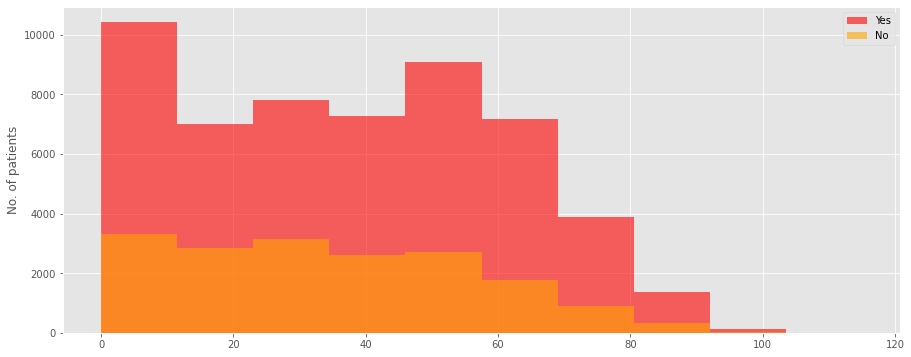

```python
# Use this, and more code cells, to explore your data. Don't forget to add
#   Markdown cells to document your observations and findings.
plt.figure(figsize=[15,6])
df['Age'][show].hist(color="red",alpha=0.6,label="Yes")
df['Age'][noshow].hist(color="orange",alpha=0.6,label="No")
plt.legend()
plt.ylabel("No. of patients")
```

#### At age 0-10 are the most attending age group though there are a lot of difference between other ages.

### This is made to simplify all these ages to groups of ages to simplify the data

```python
bins=[0,3,12,19,30,50,120]
index_age_grp=['toddler','kid','teen','young','adult','old']
df['age_group']=pd.cut(df["Age"],bins,labels=index_age_grp)
#now lets try group by again
```

```python
age_show =df.groupby(['age_group'])['show'].sum()
age_show
```

```
age_group
toddler     3050
kid         6079
teen        4462
young       7024
adult      13662
old        18048
Name: show, dtype: int64
```

### Great! Now I can visualize the following in a bar chart!

### Conclusion: Apparently its most likely an old or adult person would show up for an appointment than any other age group!

#### Note: This is contradicting the histogram above, This is because "Old" age group is a wide range of ages from 50 to 120 meanwhile toddlers and kids are very short ranges. this show that the majority of attendance is from old and adult people but a specific age that attends the most is 0~10 years old

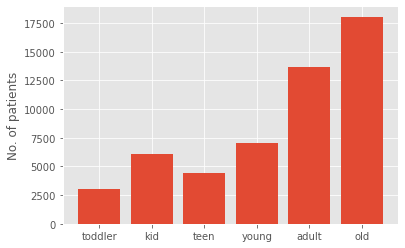

```python
plt.bar(index_age_grp,age_show)
plt.ylabel("No. of patients")
```

### Question 2: Does long term dieseases have an affect on the appointment attendace ?

### Here I am extracting different dataframes that has people with different diseases/handicaps.

```python
# Continue to explore the data to address your additional research
#   questions. Add more headers as needed if you have more questions to
#   investigate.

Hypertension_df=df.query("Hypertension == 1")
Diabetes_df=df.query("Diabetes == 1")
Alcoholism_df=df.query("Alcoholism == 1")
Handcap_df=df.query("Handcap == 1")
no_Hypertension_df=df.query("Hypertension == 0")
no_Diabetes_df=df.query("Diabetes == 0")
no_Alcoholism_df=df.query("Alcoholism == 0")
no_Handcap_df=df.query("Handcap == 0")
```

```python
Diabetes_show=df.groupby(['Diabetes'])["show"].sum()[1]
Alcoholism_show=df.groupby(['Alcoholism'])["show"].sum()[1]
Hypertension_show=df.groupby(['Hypertension'])["show"].sum()[1]
Handcap_show=df.groupby(['Handcap'])["show"].sum()[1]
index_D_show=['Diabetes','Alcoholism','Hypertension','Handcap']


Diabetes_show
```

```
3946
```

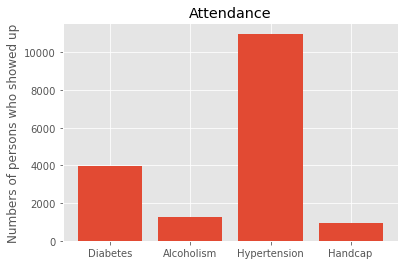

```python
plt.bar(index_D_show,[Diabetes_show,Alcoholism_show,Hypertension_show,Handcap_show])
plt.title('Attendance')
plt.ylabel('Numbers of persons who showed up')
```

```python
HP=Hypertension_df.show.value_counts(1)[1]*100
DP=Diabetes_df.show.value_counts(1)[1]*100
AP=Alcoholism_df.show.value_counts(1)[1]*100
HPP=Handcap_df.show.value_counts(1)[1]*100
NHP=no_Hypertension_df.show.value_counts(1)[1]*100
NDP=no_Diabetes_df.show.value_counts(1)[1]*100
NAP=no_Alcoholism_df.show.value_counts(1)[1]*100
NHPP=no_Handcap_df.show.value_counts(1)[1]*100
```

### This plot shows that there is very little to no correlation between attendance and diseases as percentages are quite close to each other with people who attened and who didn't

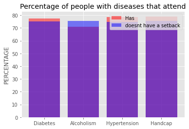

```python
plt.bar(index_D_show,[DP,AP,HP,HPP], color="red",alpha = 0.5,label="Has")
plt.bar(index_D_show,[NDP,NAP,NHP,NHPP], color="blue",alpha = 0.5,label="doesnt have a setback")
plt.title("Percentage of people with diseases that attend")
plt.ylabel("PERCENTAGE")
plt.legend()
```

## Question 3 : How scholarships and SMS messages influence the attendance

```python
scholar_Q=df.query("Scholarship == 1")
sms_Q=df.query("SMS_received==1")
no_scholar_Q=df.query("Scholarship == 0")
no_sms_Q=df.query("SMS_received==0")
```

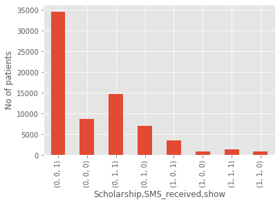

```python
df.groupby(['Scholarship','SMS_received'])["show"].value_counts().plot(kind='bar')
plt.ylabel("No of patients")
```

#### this plot shows that no relation between people attending or not but there is a huge issue where people who attended without SMS messages showed up more than people who attended with recieving them. This means the SMS messages system that is used is ineffective and is not pumping messages to patients as supposed to be.

### Here SMS has lower attendance than without SMS messages sent meanwhile Scholarship has little effect

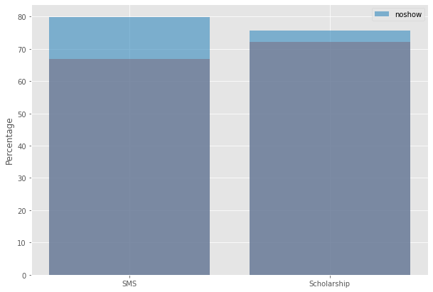

```python
SQ=scholar_Q.show.value_counts(1)[1]*100
SMSQ=sms_Q.show.value_counts(1)[1]*100
NSQ=no_scholar_Q.show.value_counts(1)[1]*100
NSMSQ=no_sms_Q.show.value_counts(1)[1]*100
plt.figure(figsize=[10,7])
plt.bar(['SMS','Scholarship'],[SMSQ,SQ],alpha=0.6)
plt.bar(['SMS','Scholarship'],[NSMSQ,NSQ], alpha=0.6,label="noshow")
plt.legend()
plt.ylabel("Percentage")
```

### Question 4 : Does Gender ratio attendance differ ?

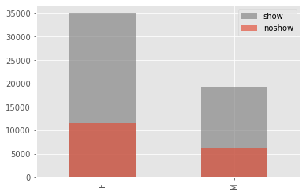

```python
df.Gender[show].value_counts().plot(kind="bar", alpha=0.65,label="show", color="Grey")

df.Gender[noshow].value_counts().plot(kind="bar", alpha=0.65,label="noshow")
plt.legend()
```

```python
Gender_show=df.Gender[show].value_counts()
Gender_noshow=df.Gender[noshow].value_counts()
```

```python
attending_females=df.Gender[show].value_counts()[0]
attending_males=df.Gender[show].value_counts()[1]
```

```python
N_attending_females=df.Gender[noshow].value_counts()[0]
N_attending_males=df.Gender[noshow].value_counts()[1]
```

```python
fem_percent=[attending_females,N_attending_females]
male_percent=[attending_males,N_attending_males]
```

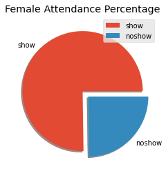

```python
plt.pie(fem_percent,labels=["show","noshow"],explode=[0,0.13],shadow=True)
plt.title("Female Attendance Percentage")
plt.legend()
```

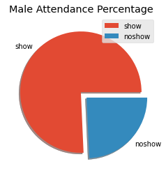

```python
plt.pie(male_percent,labels=["show","noshow"],explode=[0,0.13],shadow=True)
plt.title("Male Attendance Percentage")
plt.legend()
```

```python
print(Gender_show)
print(Gender_noshow)
```

```
F    34960
M    19193
Name: Gender, dtype: int64
F    11506
M     6157
Name: Gender, dtype: int64
```

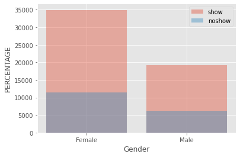

```python
plt.bar(['Female','Male'],Gender_show,alpha=0.4,label="show")
plt.bar(['Female','Male'],Gender_noshow,alpha=0.4,label="noshow")
plt.legend()
plt.xlabel("Gender")
plt.ylabel("PERCENTAGE")
```

#### This shows that there is no correlation at all between Gender and attendance as the percentages of Genders showing and not showing are almost the same.

### Neighbourhood relations:

```python
#Checking for the neighbourhood with most shows
df.groupby(['Neighbourhood'])["show"].sum().max()
df.groupby(['Neighbourhood'])["show"].sum().idxmax()
```

```
'JARDIM CAMBURI'
```

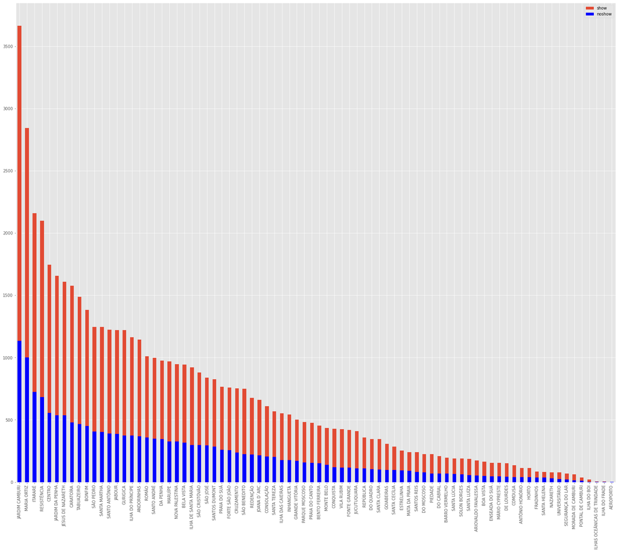

```python
df['Neighbourhood'][show].value_counts().plot(kind="bar",figsize=(15,12),label="show")
plt.subplots_adjust(plt.subplots_adjust(left=0.1,
                    bottom=0.1,
                    right=1.5,
                    top=1.5))
df['Neighbourhood'][noshow].value_counts().plot(kind="bar",figsize=(15,12),color="blue",label="noshow")
plt.subplots_adjust(plt.subplots_adjust(left=0.1,
                    bottom=0.1,
                    right=1.5,
                    top=1.5))
plt.legend()
```

### Let's dive deeper!

```python
df.head()
```

|  | Gender | Age | Neighbourhood | Scholarship | Diabetes | Alcoholism | Handcap | SMS_received | No_show | Hypertension | show | age_group |
| --- | --- | --- | --- | --- | --- | --- | --- | --- | --- | --- | --- | --- |
| 0 | F | 62 | JARDIM DA PENHA | 0 | 0 | 0 | 0 | 0 | No | 1 | 1 | old |
| 1 | M | 56 | JARDIM DA PENHA | 0 | 0 | 0 | 0 | 0 | No | 0 | 1 | old |
| 2 | F | 62 | MATA DA PRAIA | 0 | 0 | 0 | 0 | 0 | No | 0 | 1 | old |
| 3 | F | 8 | PONTAL DE CAMBURI | 0 | 0 | 0 | 0 | 0 | No | 0 | 1 | kid |
| 4 | F | 56 | JARDIM DA PENHA | 0 | 1 | 0 | 0 | 0 | No | 1 | 1 | old |

```python
old_df=df[df.Age >30]
```

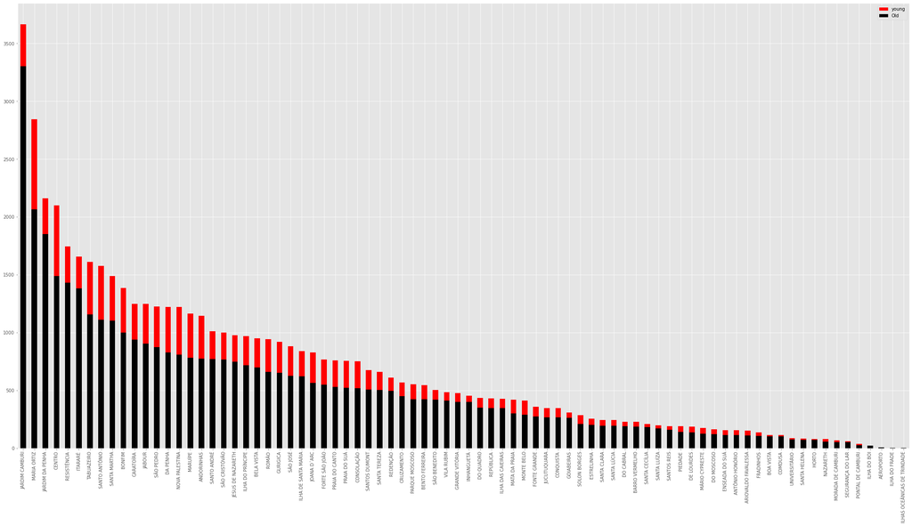

```python
df['Neighbourhood'][show].value_counts().plot(kind="bar",figsize=(15,12),color="Red",label="young")
plt.subplots_adjust(plt.subplots_adjust(left=0.1,
                    bottom=0.1,
                    right=1.5,
                    top=1.5))
old_df.Neighbourhood.value_counts().plot(kind='bar',figsize=(20,10),color="Black",label="Old")
plt.subplots_adjust(plt.subplots_adjust(left=0.1,
                    bottom=0.1,
                    right=1.5,
                    top=1.5))
plt.legend()
```

```python
scholar_Q=df.query("Scholarship == 1")
sms_Q=df.query("SMS_received==1")
no_scholar_Q=df.query("Scholarship == 0")
no_sms_Q=df.query("SMS_received==0")
```

```python
show_sms=sms_Q[sms_Q['show']==1]
no_show_sms=sms_Q[sms_Q['show']==0]
```

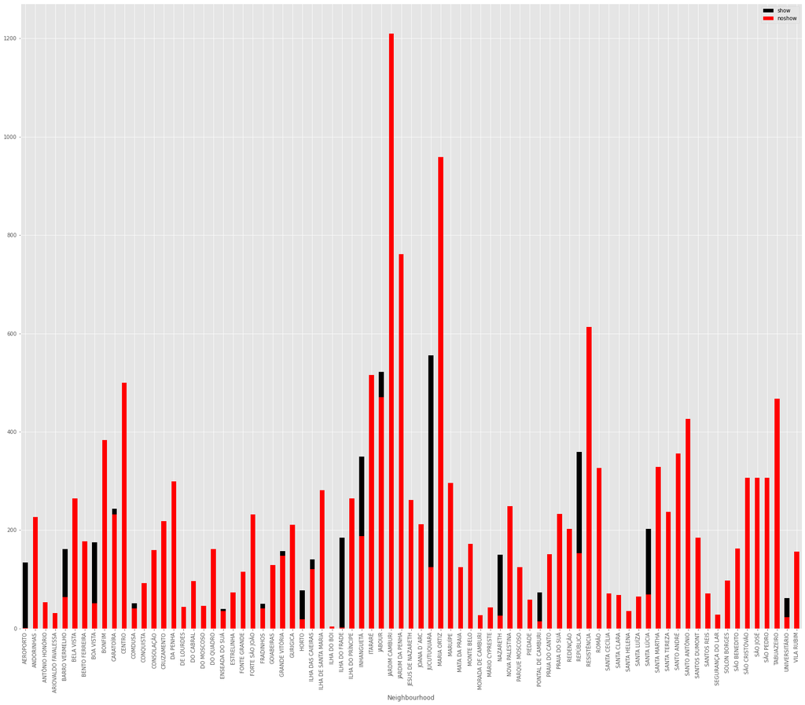

```python
no_show_sms[noshow].groupby(["Neighbourhood"])["show"].count().plot(kind="bar",figsize=(15,12),color="Black",label="show")
plt.subplots_adjust(plt.subplots_adjust(left=0.1,
                    bottom=0.1,
                    right=1.5,
                    top=1.5))
show_sms.groupby(["Neighbourhood"])["show"].sum().plot(kind="bar",figsize=(15,12),color="Red",label="noshow")
plt.subplots_adjust(plt.subplots_adjust(left=0.1,
                    bottom=0.1,
                    right=1.5,
                    top=1.5))

plt.legend()
```

## Conclusions

#### Gender has no correlation with attendance at all.

#### scholarship to brasil familia has little to no effect on the attendance percentage